# Statistics Case Study: Cross Fell Grazing 2013

CK

24 August 2017

### Time run

Time run: 2017-09-07 08:48:06

### Packages

```r
library(tidyverse)
library(lubridate)
library(knitr)
```

## Data preparation

### Import data - cover part

Import the csv file provided

```r
raw <- read.csv(file = "CROSS FELL COVER ALL.csv", sep = ",", quote = "",  header = T, skipNul = T)
```

### Wrangle data - cover

#### Names

lets have a look at the names:

```r
names(raw)
```

```
 [1] "Vm.03."     "Vm.05."     "Vm.08."     "Vm.10."     "VM13."      "C6"
 [7] "C7.T"       "Vmb.03."    "Vmb.05."    "Vmb.08."    "Vmb.10."    "Vmb13."
[13] "C13"        "C14.T"      "moss.03."   "moss.05."   "moss.08."   "moss.10."
[19] "moss.13."   "DV.03"      "DV.05"      "DV.08"      "DV.10"      "DV.13"
[25] "C25"        "C26.T"      "ln.moss03"  "ln.moss.05" "ln.moss08"  "ln.moss10"
[31] "dung.03"    "dung.05"    "dung.10"    "dung.13"    "C35"        "C36.T"
```

They are a bit of a mess.

We can strip out a lot automatically, and replace some of the more exotic characters. Here I will remove the periods and replace `VM13.` with `Vm13` as names in **R** are case sensitive.

```r
names(raw) <- gsub("\\.", "", names(raw))
colnames(raw)[5] <- c("Vm13")
#colnames(raw)
```

#### Strip

We’ve got some unnecessary summary columns: They all start with `C`. We’ll strip them out:

```r
raw[,grep("C", names(raw))] <- NULL
#names(raw)
```

DM has advised:

> Vmb – b indicates a version of the data with a couple of outliers – 10% cover – removed in 2008

So I am going to use the version without outliers (Vmb) as this is what DM did. I’ll delete all the Vm columns, and I’ll subsequently rename Vmb to Vm:

```r
raw[c("Vm03", "Vm05", "Vm08", "Vm10", "Vm13")] <- NULL
colnames(raw)[1:5] <- c("Vm03", "Vm05", "Vm08", "Vm10", "Vm13")
#names(raw)
```

Finally we’ve got the natural log of moss, which we’ll remove, because it is a derrived value and at this stage we only want the observations.

```r
raw[,grep("lnmoss", names(raw))] <- NULL
names(raw)
```

```
 [1] "Vm03"   "Vm05"   "Vm08"   "Vm10"   "Vm13"   "moss03" "moss05" "moss08" "moss10"
[10] "moss13" "DV03"   "DV05"   "DV08"   "DV10"   "DV13"   "dung03" "dung05" "dung10"
[19] "dung13"
```

#### Make tidy

Now lets put this into [**tidy**](http://r4ds.had.co.nz/tidy-data.html#tidy-data-1) format:

> 1. Each **variable** must have its own **column**.
> 2. Each **observation** must have its own **row**.
> 3. Each **value** must have its own **cell**.

In this case the observations are of percent cover, and they key (currently column names) define a taxon and a year.

```r
cov.data <- gather(data = raw, key = "tax.surv", value = "cover", na.rm = TRUE, factor_key = TRUE)
head(cov.data) #have a look
```

|  | tax.surv | cover |
| --- | --- | --- |
| 1 | Vm03 | 0.0 |
| 2 | Vm03 | 0.5 |
| 3 | Vm03 | 0.0 |
| 4 | Vm03 | 0.5 |
| 5 | Vm03 | 0.0 |
| 6 | Vm03 | 0.0 |

```r
dim(cov.data) #get dimensions
```

```
[1] 732   2
```

```r
levels(cov.data$tax.surv) #check all the variables are there
```

```
 [1] "Vm03"   "Vm05"   "Vm08"   "Vm10"   "Vm13"   "moss03" "moss05" "moss08" "moss10"
[10] "moss13" "DV03"   "DV05"   "DV08"   "DV10"   "DV13"   "dung03" "dung05" "dung10"
[19] "dung13"
```

Now we need to split the `tax.surv` column.

```r
cov.data <- separate(data = cov.data, col = tax.surv, into = c("taxon", "year"), sep = -3)
cov.data$taxon <- as.factor(cov.data$taxon)
levels(cov.data$taxon)
```

```
[1] "dung" "DV"   "moss" "Vm"
```

```r
head(cov.data)
```

|  | taxon | year | cover |
| --- | --- | --- | --- |
| 1 | Vm | 03 | 0.0 |
| 2 | Vm | 03 | 0.5 |
| 3 | Vm | 03 | 0.0 |
| 4 | Vm | 03 | 0.5 |
| 5 | Vm | 03 | 0.0 |
| 6 | Vm | 03 | 0.0 |

```r
summary(cov.data)
```

```
  taxon         year               cover
 dung:168   Length:732         Min.   :  0.000
 DV  :189   Class :character   1st Qu.:  0.000
 moss:189   Mode  :character   Median :  1.000
 Vm  :186                      Mean   :  6.738
                               3rd Qu.:  5.000
                               Max.   :100.000
```

Finally sort out the `year` column:

```r
cov.data$year[which(cov.data$year=="03")] <- 2003
cov.data$year[which(cov.data$year=="05")] <- 2005
cov.data$year[which(cov.data$year=="08")] <- 2008
cov.data$year[which(cov.data$year=="10")] <- 2010
cov.data$year[which(cov.data$year=="13")] <- 2013
cov.data$year <- as.factor(cov.data$year)
levels(cov.data$year) <- c("2003", "2005", "2008", "2010", "2013")
```

we good?

```r
summary(cov.data)
```

```
  taxon       year         cover
 dung:168   2003:168   Min.   :  0.000
 DV  :189   2005:176   1st Qu.:  0.000
 moss:189   2008: 60   Median :  1.000
 Vm  :186   2010:131   Mean   :  6.738
            2013:197   3rd Qu.:  5.000
                       Max.   :100.000
```

**we good.**

### Import data - height

Import the csv file which I previously opened in Minitab and saved (probably wrongly in Unicode)

```r
raw <- read.csv(file = "CROSS FELL HEIGHT ALL.csv", sep = ",", quote = "",  header = T, skipNul = T)
```

### Wrangle data - height

#### Names

lets have a look at the names:

```r
names(raw)
```

```
 [1] "mossht.03" "mossht.05" "mossht.08" "mossht.10" "mossht.13" "Vm.ht.03"  "Vm.ht.05"
 [8] "Vm.ht.08"  "Vm.ht.10"  "Vm.ht.13"  "Fo.ht.03"  "Fo.ht.05"  "Fo.ht.08"  "Fo.ht.10"
[15] "Fo.ht.13"  "Cx.ht.03"  "Cx.ht.05"  "Cx.ht.08"  "Cx.ht.10"  "Cx.ht.13"  "grm.ht.03"
[22] "grm.ht.05" "grm.ht.08" "grm.ht.10" "grm.ht.13" "C26"       "C27.T"     "C28"
[29] "C29.T"     "C31"       "C32.T"
```

```r
names(raw) <- gsub("ht", "", names(raw))
names(raw) <- gsub("X.", "", names(raw))
names(raw) <- gsub("\\.", "", names(raw))
names(raw)
```

```
 [1] "moss03" "moss05" "moss08" "moss10" "moss13" "Vm03"   "Vm05"   "Vm08"   "Vm10"
[10] "Vm13"   "Fo03"   "Fo05"   "Fo08"   "Fo10"   "Fo13"   "Cx03"   "Cx05"   "Cx08"
[19] "Cx10"   "Cx13"   "grm03"  "grm05"  "grm08"  "grm10"  "grm13"  "C26"    "C27T"
[28] "C28"    "C29T"   "C31"    "C32T"
```

#### Strip

We’ve got some unnecessary summary columns: They all start with `C`. We’ll strip them out:

```r
raw[,grep("C", names(raw))] <- NULL
#names(raw)
```

#### Make tidy

Now lets put this into **tidy** format.

```r
ht.data <- gather(data = raw, key = "tax.surv", value = "height", na.rm = TRUE, factor_key = TRUE)
head(ht.data) #have a look
```

|  | tax.surv | height |
| --- | --- | --- |
| 1 | moss03 | 2.5 |
| 2 | moss03 | 4.5 |
| 3 | moss03 | 3.0 |
| 4 | moss03 | 2.0 |
| 5 | moss03 | 3.0 |
| 6 | moss03 | 4.0 |

```r
dim(ht.data) #get dimensions
```

```
[1] 1525    2
```

```r
levels(ht.data$tax.surv) #check all the variables are there
```

```
 [1] "moss03" "moss05" "moss08" "moss10" "moss13" "Vm03"   "Vm05"   "Vm08"   "Vm10"
[10] "Vm13"   "Fo03"   "Fo05"   "Fo08"   "Fo10"   "Fo13"   "grm03"  "grm05"  "grm08"
[19] "grm10"  "grm13"
```

Now we need to split the `tax.surv` column.

```r
ht.data <- separate(data = ht.data, col = tax.surv, into = c("taxon", "year"), sep = -3)
ht.data$taxon <- as.factor(ht.data$taxon)
levels(ht.data$taxon)
```

```
[1] "Fo"   "grm"  "moss" "Vm"
```

```r
head(ht.data)
```

|  | taxon | year | height |
| --- | --- | --- | --- |
| 1 | moss | 03 | 2.5 |
| 2 | moss | 03 | 4.5 |
| 3 | moss | 03 | 3.0 |
| 4 | moss | 03 | 2.0 |
| 5 | moss | 03 | 3.0 |
| 6 | moss | 03 | 4.0 |

```r
summary(ht.data)
```

```
  taxon         year               height
 Fo  :385   Length:1525        Min.   : 0.500
 grm :729   Class :character   1st Qu.: 2.500
 moss:183   Mode  :character   Median : 3.500
 Vm  :228                      Mean   : 4.071
                               3rd Qu.: 5.000
                               Max.   :17.000
```

Finally sort out the `year` column:

```r
ht.data$year[which(ht.data$year=="03")] <- 2003
ht.data$year[which(ht.data$year=="05")] <- 2005
ht.data$year[which(ht.data$year=="08")] <- 2008
ht.data$year[which(ht.data$year=="10")] <- 2010
ht.data$year[which(ht.data$year=="13")] <- 2013
ht.data$year <- as.factor(ht.data$year)
levels(ht.data$year) <- c("2003", "2005", "2008", "2010", "2013")
```

*we good?*

```r
summary(ht.data)
```

```
  taxon       year         height
 Fo  :385   2003:361   Min.   : 0.500
 grm :729   2005:406   1st Qu.: 2.500
 moss:183   2008:181   Median : 3.500
 Vm  :228   2010:236   Mean   : 4.071
            2013:341   3rd Qu.: 5.000
                       Max.   :17.000
```

**we good.**

### Import data - all quadrat data

Import minitab file

```r
#raw <- read.table("cross fell cover all.MTP", quote="", comment.char="", skip = 2)
```

*not working, have asked DM for csv*

###Merge data

*we can’t do this at the moment because we don’t have the quadrat data*

###Contextual data

####Quadrats

Number of quadrats surveyed per year (taken from report)

```r
quad.n <- data.frame(year = c("2003", "2005", "2008", "2010", "2013"), n.total = c(42, 44, 20, 31, 56))
```

## Data analysis

### Exploratory data anlysis

#### plot cover values:

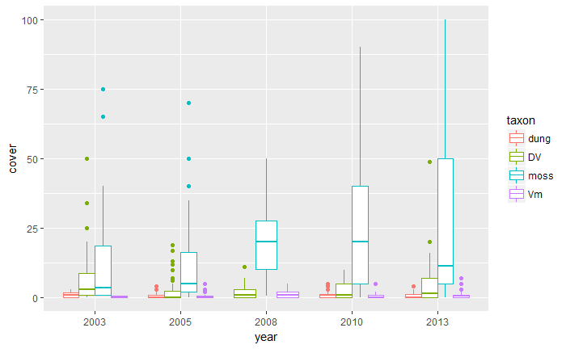

```r
ggplot(data = cov.data, mapping = aes(y = cover, x = year)) +
  geom_boxplot(aes(colour = taxon))
```

Looks good. `moss` is most common, some sort of pattern maybe.

#### look at means:

```r
cov.means <- cov.data %>%
  group_by(taxon, year) %>%
  summarise(mean = mean(cover), median = median(cover), sd = sd(cover),
            present = length(cover[which(cover!=0)]), n = length(cover))
kable(cov.means, digits = 2, caption = "Mean percent cover")
```

| taxon | year | mean | median | sd | present | n |
| --- | --- | --- | --- | --- | --- | --- |
| dung | 2003 | 1.12 | 1.0 | 0.99 | 30 | 42 |
| dung | 2005 | 0.73 | 0.0 | 1.07 | 20 | 45 |
| dung | 2010 | 1.06 | 1.0 | 1.30 | 19 | 33 |
| dung | 2013 | 0.88 | 0.0 | 1.23 | 21 | 48 |
| DV | 2003 | 7.43 | 3.0 | 10.35 | 32 | 42 |
| DV | 2005 | 2.59 | 0.0 | 4.72 | 19 | 44 |
| DV | 2008 | 2.10 | 1.0 | 2.79 | 14 | 20 |
| DV | 2010 | 2.27 | 1.0 | 3.02 | 18 | 33 |
| DV | 2013 | 4.92 | 1.5 | 8.22 | 32 | 50 |
| moss | 2003 | 12.95 | 3.5 | 19.72 | 42 | 42 |
| moss | 2005 | 12.34 | 5.0 | 14.99 | 44 | 44 |
| moss | 2008 | 22.48 | 20.0 | 15.46 | 20 | 20 |
| moss | 2010 | 26.82 | 20.0 | 24.67 | 31 | 33 |
| moss | 2013 | 28.84 | 11.5 | 30.85 | 47 | 50 |
| Vm | 2003 | 0.14 | 0.0 | 0.23 | 12 | 42 |
| Vm | 2005 | 0.69 | 0.0 | 1.34 | 19 | 43 |
| Vm | 2008 | 1.05 | 1.0 | 1.22 | 13 | 20 |
| Vm | 2010 | 0.80 | 0.0 | 1.33 | 14 | 32 |
| Vm | 2013 | 0.84 | 0.5 | 1.45 | 25 | 49 |

#### plot vegetation heights:

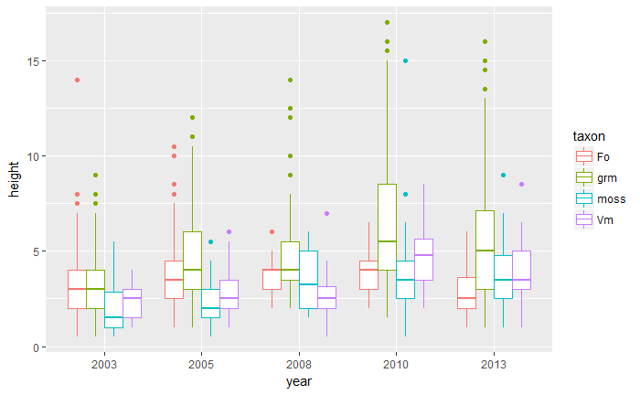

```r
ggplot(data = ht.data, mapping = aes(y = height, x = year)) +
  geom_boxplot(aes(colour = taxon))
```

#### Height means:

```r
ht.means <- ht.data %>%
  group_by(taxon, year) %>%
  summarise(mean = mean(height), median = median(height), sd = sd(height),
            present = length(height[which(height!=0)]), n = length(height))
kable(ht.means, digits = 2, caption = "Mean vegetation height")
```

| taxon | year | mean | median | sd | present | n |
| --- | --- | --- | --- | --- | --- | --- |
| Fo | 2003 | 3.11 | 3.00 | 1.87 | 131 | 131 |
| Fo | 2005 | 3.78 | 3.50 | 1.71 | 134 | 134 |
| Fo | 2008 | 3.88 | 4.00 | 0.92 | 37 | 37 |
| Fo | 2010 | 3.89 | 4.00 | 1.19 | 35 | 35 |
| Fo | 2013 | 2.86 | 2.50 | 1.13 | 48 | 48 |
| grm | 2003 | 3.28 | 3.00 | 1.66 | 167 | 167 |
| grm | 2005 | 4.45 | 4.00 | 2.24 | 176 | 176 |
| grm | 2008 | 5.04 | 4.00 | 2.63 | 80 | 80 |
| grm | 2010 | 6.45 | 5.50 | 3.43 | 130 | 130 |
| grm | 2013 | 5.63 | 5.00 | 3.20 | 176 | 176 |
| moss | 2003 | 1.95 | 1.50 | 1.30 | 42 | 42 |
| moss | 2005 | 2.37 | 2.00 | 1.13 | 43 | 43 |
| moss | 2008 | 3.48 | 3.25 | 1.59 | 20 | 20 |
| moss | 2010 | 3.85 | 3.50 | 2.63 | 31 | 31 |
| moss | 2013 | 3.81 | 3.50 | 1.68 | 47 | 47 |
| Vm | 2003 | 2.40 | 2.50 | 0.94 | 21 | 21 |
| Vm | 2005 | 2.88 | 2.50 | 1.15 | 53 | 53 |
| Vm | 2008 | 2.58 | 2.50 | 1.21 | 44 | 44 |
| Vm | 2010 | 4.66 | 4.75 | 1.73 | 40 | 40 |
| Vm | 2013 | 3.68 | 3.50 | 1.52 | 70 | 70 |

#### recreate table from report

Now lets recreate the table of mean heights from the report (Table 1)

```r
Table1 <- spread(data = select(.data = ht.means, taxon, year, mean),
                 key = year,
                 value = mean)
knitr::kable(Table1, digits = 2, caption = "Table 1: Mean height of key species groups measured in each survey year")
```

| taxon | 2003 | 2005 | 2008 | 2010 | 2013 |
| --- | --- | --- | --- | --- | --- |
| Fo | 3.11 | 3.78 | 3.88 | 3.89 | 2.86 |
| grm | 3.28 | 4.45 | 5.04 | 6.45 | 5.63 |
| moss | 1.95 | 2.37 | 3.48 | 3.85 | 3.81 |
| Vm | 2.40 | 2.88 | 2.58 | 4.66 | 3.68 |

#### Frequencies

Lets try to calculate frequencies

```r
freq <- cov.means[,c("taxon", "year", "present", "n")]
freq <- full_join(freq, quad.n, by = "year")
freq$freq.n.total <- freq$present / freq$n.total
freq$freq.n <- freq$present / freq$n
kable(freq, digits = 2, caption = "Frequency: number and proportion of quadrats in which taxon was found")
```

| taxon | year | present | n | n.total | freq.n.total | freq.n |
| --- | --- | --- | --- | --- | --- | --- |
| dung | 2003 | 30 | 42 | 42 | 0.71 | 0.71 |
| dung | 2005 | 20 | 45 | 44 | 0.45 | 0.44 |
| dung | 2010 | 19 | 33 | 31 | 0.61 | 0.58 |
| dung | 2013 | 21 | 48 | 56 | 0.38 | 0.44 |
| DV | 2003 | 32 | 42 | 42 | 0.76 | 0.76 |
| DV | 2005 | 19 | 44 | 44 | 0.43 | 0.43 |
| DV | 2008 | 14 | 20 | 20 | 0.70 | 0.70 |
| DV | 2010 | 18 | 33 | 31 | 0.58 | 0.55 |
| DV | 2013 | 32 | 50 | 56 | 0.57 | 0.64 |
| moss | 2003 | 42 | 42 | 42 | 1.00 | 1.00 |
| moss | 2005 | 44 | 44 | 44 | 1.00 | 1.00 |
| moss | 2008 | 20 | 20 | 20 | 1.00 | 1.00 |
| moss | 2010 | 31 | 33 | 31 | 1.00 | 0.94 |
| moss | 2013 | 47 | 50 | 56 | 0.84 | 0.94 |
| Vm | 2003 | 12 | 42 | 42 | 0.29 | 0.29 |
| Vm | 2005 | 19 | 43 | 44 | 0.43 | 0.44 |
| Vm | 2008 | 13 | 20 | 20 | 0.65 | 0.65 |
| Vm | 2010 | 14 | 32 | 31 | 0.45 | 0.44 |
| Vm | 2013 | 25 | 49 | 56 | 0.45 | 0.51 |

##### Problems:

- there are cases where the number of observations `n` is higher than the number of quadrats were surveyed according to the report `n.total`.

More observations than reported quadrats

| taxon | year | n | n.total |
| --- | --- | --- | --- |
| dung | 2005 | 45 | 44 |
| dung | 2010 | 33 | 31 |
| DV | 2010 | 33 | 31 |
| moss | 2010 | 33 | 31 |
| Vm | 2010 | 32 | 31 |

Will need to check the full data when we get it. For the time being we’ll use `n` the total number of observations calculated from the number of records (including 0 values), rather than `n.total` the reported number.

- the data doesn’t quite tally with the report, e.g. bilberry in 2013 was found in 25 quadrats, but report says 30.  
  ####Table Frequencies by year and taxon

```r
TableFreq <- spread(data = select(.data = freq, taxon, year, freq.n),
                    key = year,
                    value = freq.n)
knitr::kable(TableFreq, digits = 2, caption = "Frequency: proportion of quadrats in which taxon was found")
```

| taxon | 2003 | 2005 | 2008 | 2010 | 2013 |
| --- | --- | --- | --- | --- | --- |
| dung | 0.71 | 0.44 | NA | 0.58 | 0.44 |
| DV | 0.76 | 0.43 | 0.70 | 0.55 | 0.64 |
| moss | 1.00 | 1.00 | 1.00 | 0.94 | 0.94 |
| Vm | 0.29 | 0.44 | 0.65 | 0.44 | 0.51 |

# Replicate report

## 4.2 Vegetation condition

### 4.2.1 Dominant Graminoids

> In 2013, sheep’s fescue (Festuca ovina) was recorded as being the dominant graminoid in 14 (25%) of quadrats (figure 2), with an average sward height of 2.86 cm (table 1). Stiff sedge (Carex bigelowii) was recorded as dominant in 33(59%) quadrats, with an average sward height of 6.94 cm. From figure 2 it can be seen that the proportion of quadrats in which sheep’s fescue is dominant has steadily decreased from 81% in 2003, whilst the proportion in which stiff sedge is judged to be dominant has increased from 14.3%.

> Figure 2. The proportion of quadrats in which sheep’s fescue and stiff sedge are dominant in each survey, 2003 – 2010.

Cannot replicate this, because we don’t have the species data available.

> Table 1. Mean height of key species groups measured in each survey year

| Species | 2003 | 2005 | 2008 | 2010 | 2013 |
| --- | --- | --- | --- | --- | --- |
| Bilberry | 2.4a | 2.88a | 2.58a | 4.66c | 3.53b |
| Sheep’s fescue | 3.11a | 3.78b | 3.88ab | 3.89ab | 2.86a |
| Stiff sedge | 4.2a | 7.13b | 6.56b | 7.56b | 6.94b |
| Moss/ lichen | 1.95a | 2.37a | 3.48b | 3.48b | 3.56b |
| All graminoids | 3.28a | 4.46b | 5.04bc | 6.45d | 5.75cd |

| Species | 2003 | 2005 | 2008 | 2010 | 2013 |
| --- | --- | --- | --- | --- | --- |
| Bilberry | 2.40 | 2.88 | 2.58 | 4.66 | 3.68 |
| Sheep's Fescue | 3.11 | 3.78 | 3.88 | 3.89 | 2.86 |
| Moss/ lichen | 1.95 | 2.37 | 3.48 | 3.85 | 3.81 |
| All graminoids | 3.28 | 4.45 | 5.04 | 6.45 | 5.63 |

#### Carry out ANOVA on just one taxon

```r
aov.moss <- aov(data = dplyr::filter(ht.data, taxon == "moss"), formula = height ~ year)
anova(aov.moss)
```

```
Analysis of Variance Table

Response: height
           Df Sum Sq Mean Sq F value    Pr(>F)
year        4 120.89 30.2222  10.547 1.085e-07 ***
Residuals 178 510.06  2.8655
---
Signif. codes:  0 ‘***’ 0.001 ‘**’ 0.01 ‘*’ 0.05 ‘.’ 0.1 ‘ ’ 1
```

```r
print(model.tables(aov.moss, "means"), digits = 3)
```

```
Tables of means
Grand mean

3.016393

 year
     2003  2005  2008  2010  2013
     1.95  2.37  3.47  3.85  3.81
rep 42.00 43.00 20.00 31.00 47.00
```

```r
model.tables(x = aov.moss)
```

```
Tables of effects

 year
      2003    2005    2008    2010    2013
    -1.064 -0.6443  0.4586  0.8384  0.7921
rep 42.000 43.0000 20.0000 31.0000 47.0000
```

```r
tuk.moss <- TukeyHSD(aov.moss)
tuk.moss
```

```
  Tukey multiple comparisons of means
    95% family-wise confidence level

Fit: aov(formula = height ~ year, data = dplyr::filter(ht.data, taxon == "moss"))

$year
                 diff        lwr      upr     p adj
2005-2003  0.41971207 -0.5923851 1.431809 0.7834771
2008-2003  1.52261905  0.2551778 2.790060 0.0098092
2010-2003  1.90245776  0.7978005 3.007115 0.0000414
2013-2003  1.85612969  0.8655417 2.846718 0.0000063
2008-2005  1.10290698 -0.1597712 2.365585 0.1181235
2010-2005  1.48274569  0.3835566 2.581935 0.0024715
2013-2005  1.43641762  0.4519312 2.420904 0.0008058
2010-2008  0.37983871 -0.9581759 1.717853 0.9354408
2013-2008  0.33351064 -0.9119933 1.579015 0.9473011
2013-2010 -0.04632807 -1.1257448 1.033089 0.9999555
```

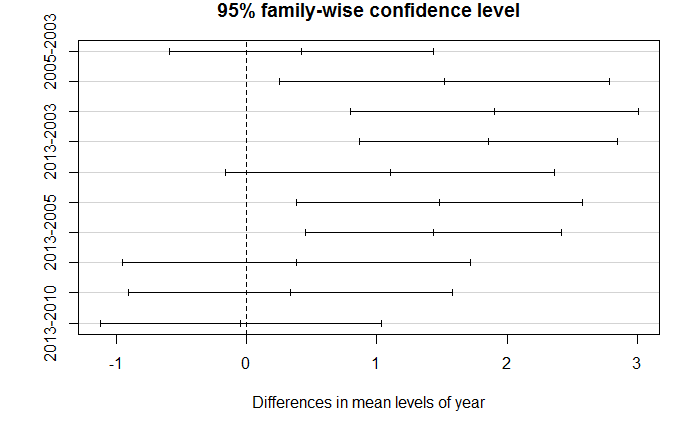

```r
plot(tuk.moss)
```

```r
tuk.moss.df <- data.frame(tuk.moss$year) %>%
  rownames_to_column("year") %>%
  separate(col = year, into = c("year2", "year1"), sep = "-") %>%
  mutate(year.diff = as.numeric(year2) - as.numeric(year1)) %>%
  arrange(p.adj) %>%
  filter(p.adj<0.05)
tuk.moss.df
```

| year2 | year1 | diff | lwr | upr | p.adj | year.diff |
| --- | --- | --- | --- | --- | --- | --- |
| 2013 | 2003 | 1.856130 | 0.8655417 | 2.846718 | 6.341884e-06 | 10 |
| 2010 | 2003 | 1.902458 | 0.7978005 | 3.007115 | 4.142908e-05 | 7 |
| 2013 | 2005 | 1.436418 | 0.4519312 | 2.420904 | 8.058158e-04 | 8 |
| 2010 | 2005 | 1.482746 | 0.3835566 | 2.581935 | 2.471500e-03 | 5 |
| 2008 | 2003 | 1.522619 | 0.2551778 | 2.790060 | 9.809183e-03 | 5 |

```r
library(userfriendlyscience)

#oneway(data = dplyr::filter(ht.data, taxon == "moss"), formula = height ~ year)
ow.moss <- oneway(y = ht.data$height, x = ht.data$year, posthoc = "tukey", means = TRUE, fullDescribe = TRUE, plot = TRUE, pvalueDigits = 3)
#class(ow.moss)
ow.moss$output

ow.moss$output$plot

plot(ow.moss$intermediate$dat)
```

[output not shown]

#### Carry out ANOVA on all taxons

```r
fit <- aov(data = ht.data, formula = height ~ year*taxon)
anova(fit)
```

```
Analysis of Variance Table

Response: height
             Df Sum Sq Mean Sq F value    Pr(>F)
year          4  957.5  239.37 50.6059 < 2.2e-16 ***
taxon         3  910.3  303.45 64.1541 < 2.2e-16 ***
year:taxon   12  287.4   23.95  5.0634 2.493e-08 ***
Residuals  1505 7118.6    4.73
---
Signif. codes:  0 ‘***’ 0.001 ‘**’ 0.01 ‘*’ 0.05 ‘.’ 0.1 ‘ ’ 1
```

```r
print(model.tables(fit), digits = 3)
```

```
Tables of effects

 year
      2003    2005     2008   2010    2013
     -1.06  -0.267  -0.0377   1.36   0.519
rep 361.00 406.000 181.0000 236.00 341.000

 taxon
         Fo     grm   moss      Vm
     -0.345   0.763  -1.11  -0.966
rep 385.000 729.000 183.00 228.000

 year:taxon
      taxon
year   Fo    grm   moss  Vm
  2003   0.5  -0.5   0.1   0.4
  rep  131.0 167.0  42.0  21.0
  2005   0.3  -0.1  -0.4   0.0
  rep  134.0 176.0  43.0  53.0
  2008   0.1   0.2   0.5  -0.6
  rep   37.0  80.0  20.0  44.0
  2010  -1.1   0.3  -0.4   0.3
  rep   35.0 130.0  31.0  40.0
  2013  -1.4   0.3   0.3   0.1
  rep   48.0 176.0  47.0  70.0
```

```r
tuk <- TukeyHSD(fit)
#tuk
class(tuk)
```

```
[1] "TukeyHSD"  "multicomp"
```

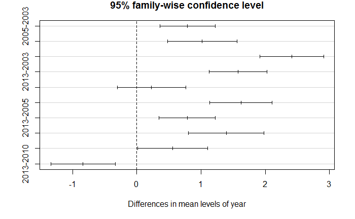

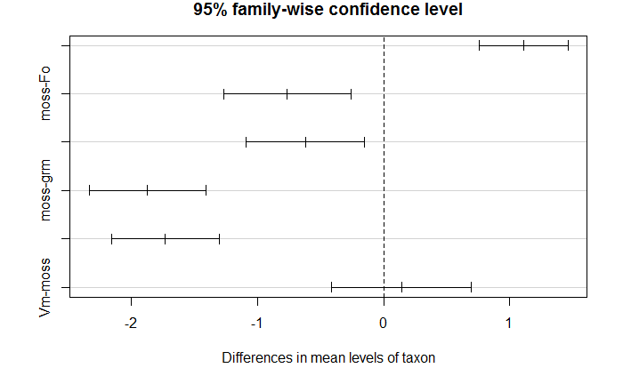

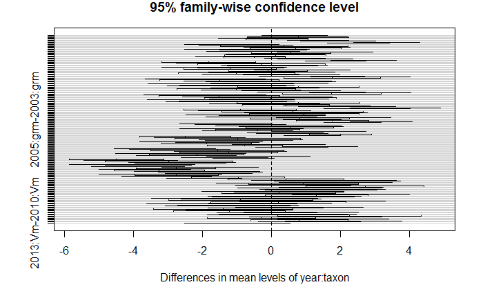

```r
plot(tuk)
```

```r
tuk$`year:taxon`
```

```
                            diff         lwr          upr        p adj
2005:Fo-2003:Fo      0.661615586 -0.28706487  1.610296039 6.028903e-01
2008:Fo-2003:Fo      0.763874562 -0.67361001  2.201359137 9.414803e-01
2010:Fo-2003:Fo      0.771210469 -0.69795068  2.240371622 9.477454e-01
2013:Fo-2003:Fo     -0.249920483 -1.55265317  1.052812207 1.000000e+00
2003:grm-2003:Fo     0.163939297 -0.73721532  1.065093912 1.000000e+00
2005:grm-2003:Fo     1.340041638  0.44907331  2.231009970 1.985564e-05
2008:grm-2003:Fo     1.929246183  0.83366227  3.024830101 9.978903e-08
2010:grm-2003:Fo     3.335496183  2.37962803  4.291364336 0.000000e+00
2013:grm-2003:Fo     2.516178001  1.62520967  3.407146334 0.000000e+00
2003:moss-2003:Fo   -1.162122864 -2.53126274  0.207017016 2.256532e-01
2005:moss-2003:Fo   -0.742410794 -2.09944192  0.614620338 9.240848e-01
2008:moss-2003:Fo    0.360496183 -1.49313314  2.214125503 1.000000e+00
2010:moss-2003:Fo    0.740334893 -0.80181318  2.282482963 9.785731e-01
2013:moss-2003:Fo    0.694006822 -0.61882921  2.006842850 9.442226e-01
2003:Vm-2003:Fo     -0.709741912 -2.52467894  1.105195116 9.981210e-01
2005:Vm-2003:Fo     -0.237145326 -1.49410224  1.019811588 1.000000e+00
2008:Vm-2003:Fo     -0.534958362 -1.88032948  0.810412757 9.976683e-01
2010:Vm-2003:Fo      1.547996183  0.15317841  2.942813961 1.267005e-02
2013:Vm-2003:Fo      0.564067612 -0.57906976  1.707204984 9.714794e-01
2008:Fo-2005:Fo      0.102258975 -1.33167732  1.536195266 1.000000e+00
2010:Fo-2005:Fo      0.109594883 -1.35609467  1.575284439 1.000000e+00
2013:Fo-2005:Fo     -0.911536070 -2.21035239  0.387280255 5.906266e-01
2003:grm-2005:Fo    -0.497676289 -1.39315997  0.397807391 9.130724e-01
2005:grm-2005:Fo     0.678426052 -0.20680609  1.563658197 4.133862e-01
2008:grm-2005:Fo     1.267630597  0.17670645  2.358554748 6.142060e-03
2010:grm-2005:Fo     2.673880597  1.72335690  3.624404298 0.000000e+00
2013:grm-2005:Fo     1.854562415  0.96933027  2.739794561 3.112666e-11
2003:moss-2005:Fo   -1.823738451 -3.18915245 -0.458324449 4.085519e-04
2005:moss-2005:Fo   -1.404026380 -2.75729829 -0.050754466 3.205515e-02
2008:moss-2005:Fo   -0.301119403 -2.15199839  1.549759587 1.000000e+00
2010:moss-2005:Fo    0.078719307 -1.46012183  1.617560446 1.000000e+00
2013:moss-2005:Fo    0.032391235 -1.27655866  1.341341127 1.000000e+00
2003:Vm-2005:Fo     -1.371357498 -3.18348547  0.440770477 4.388602e-01
2005:Vm-2005:Fo     -0.898760912 -2.15165838  0.354136556 5.473013e-01
2008:Vm-2005:Fo     -1.196573948 -2.53815318  0.145005282 1.542999e-01
2010:Vm-2005:Fo      0.886380597 -0.50478007  2.277541269 7.604880e-01
2013:Vm-2005:Fo     -0.097547974 -1.23622020  1.041124249 1.000000e+00
2010:Fo-2008:Fo      0.007335907 -1.81327201  1.827943822 1.000000e+00
2013:Fo-2008:Fo     -1.013795045 -2.70296382  0.675373729 8.405584e-01
```

[output cut: 136 more lines]

```
2003:Vm-2013:moss   -1.403748734 -3.43040895  0.622911483 6.160740e-01
2005:Vm-2013:moss   -0.931152148 -2.47818023  0.615875939 8.372032e-01
2008:Vm-2013:moss   -1.228965184 -2.84864993  0.390719559 4.335135e-01
2010:Vm-2013:moss    0.853989362 -0.80699584  2.514974566 9.570928e-01
2013:Vm-2013:moss   -0.129939210 -1.58600180  1.326123381 1.000000e+00
2005:Vm-2003:Vm      0.472596586 -1.51832126  2.463514434 9.999990e-01
2008:Vm-2003:Vm      0.174783550 -1.87310235  2.222669446 1.000000e+00
2010:Vm-2003:Vm      2.257738095  0.17703393  4.338442262 1.758285e-02
2013:Vm-2003:Vm      1.273809524 -0.64727773  3.194896780 6.957328e-01
2008:Vm-2005:Vm     -0.297813036 -1.87254505  1.276918977 1.000000e+00
2010:Vm-2005:Vm      1.785141509  0.16796060  3.402322420 1.372380e-02
2013:Vm-2005:Vm      0.801212938 -0.60467487  2.207100741 8.929388e-01
2010:Vm-2008:Vm      2.082954545  0.39613598  3.769773108 2.079500e-03
2013:Vm-2008:Vm      1.099025974 -0.38643802  2.584489969 4.847946e-01
2013:Vm-2010:Vm     -0.983928571 -2.51431952  0.546462380 7.465905e-01
```

```r
tuk.df <- data.frame(tuk$year) %>%
  rownames_to_column(var = "year") %>%
  separate(col = year, into = c("year2", "year1"), sep = "-") %>%
  mutate(year.diff = as.numeric(year2) - as.numeric(year1)) %>%
  arrange(p.adj) %>%
  filter(p.adj<0.05)
#tuk.df
```

```r
fit.aov <- aov(data = dplyr::filter(ht.data, taxon == "Fo"), formula = height ~ year)
anova(fit.aov)
```

```
Analysis of Variance Table

Response: height
           Df Sum Sq Mean Sq F value    Pr(>F)
year        4  58.86 14.7154  5.6846 0.0001878 ***
Residuals 380 983.68  2.5886
---
Signif. codes:  0 ‘***’ 0.001 ‘**’ 0.01 ‘*’ 0.05 ‘.’ 0.1 ‘ ’ 1
```

```r
fit.aov <- aov(data = dplyr::filter(ht.data, taxon == "grm"), formula = height ~ year)
anova(fit.aov)
```

```
Analysis of Variance Table

Response: height
           Df Sum Sq Mean Sq F value    Pr(>F)
year        4  881.9 220.476  30.709 < 2.2e-16 ***
Residuals 724 5198.0   7.179
---
Signif. codes:  0 ‘***’ 0.001 ‘**’ 0.01 ‘*’ 0.05 ‘.’ 0.1 ‘ ’ 1
```

```r
fit.aov <- aov(data = dplyr::filter(ht.data, taxon == "Vm"), formula = height ~ year)
anova(fit.aov)
```

```
Analysis of Variance Table

Response: height
           Df Sum Sq Mean Sq F value    Pr(>F)
year        4 133.14  33.284  17.385 1.976e-12 ***
Residuals 223 426.95   1.915
---
Signif. codes:  0 ‘***’ 0.001 ‘**’ 0.01 ‘*’ 0.05 ‘.’ 0.1 ‘ ’ 1
```

> It can be seen from table 1 that the mean height of sheep’s fescue increased significantly (p<0.005) from 3.11 cm in 2003 to 3.78 cm in 2005 (the 2005 mean value has narrower associated confidence limits for pairwise comparisons with 2003 than the 2008 and 2010 values). Further increase to 3.88 cm in 2008 and 3.89 in 2010 are however not significant, and the mean height of 2.86 cm in 2013 is significantly lower than that recorded in the three previous surveys, and not significantly different from the 2003 mean height. The mean height of stiff sedge increased significantly (p<0.001) to 7.13 cm in 2005, from 4.2 cm in 2003. In 2008 the main height was slightly lower than 2005 at 6.56 cm, before increasing to the highest recorded mean of 7.56 cm in 2010 and dropping slightly again to 6.94 cm in 2013, but these changes since 2005 are not significant. These mean height trends are also shown in figure 3.

> The mean height of all graminoid species (grasses and sedges) together are shown in figure 3 and table 1. This shows a significant (p<0.001) increase from 3.28 cm in 2003 to 6.45 cm in 2010. The mean on 5.75 cm in 2013 is slightly lower, but not significantly different.

> Figure 3. Mean height of key vegetation components: bilberry, sheep’s fescue, stiff sedge and moss and lichens